# **Active Layer Taxonomy**

Taxa plots of clean 16S OTU tables including survey and experimental samples

Kelli Feeser

2023-09-20

[Back to Home](https://kellifeeser.github.io/sctivelayer/index.html)

# Import clean OTU tables

‘Taxa’ are OTUs

# 1 Data Overview

- OTU tables rarefied to 1,096 reads / sample
- reads from ‘Survey’ and ‘Experiment’ were clustered together (OTUs correspond)
- at Domain level, only Bacteria detected
- among both datasets, a total of 1,724 unique OTUs detected
- only forward reads used

## 1.1 Survey

- n samples: 74
- n OTUs: 1,639

## 1.2 Experiment

- n samples: 55
- n OTUs: 1,402

# Set-up taxonomy for plotting

## 1.3 Global: Calculate mean relative abundance by tax rank and export csv of relative abundance

### 1.3.1 merge samples within dataset

### 1.3.2 tax glom and export

(no generating code just copy and replace)

## 1.4 Samples: Calculate relative abundance by tax rank and export csv of relative abundance

1. create vectors of top 10 taxa names to plot for all ranks
- auto-generated code found:
1. set minimum threshold of 0.5% all-sample (a.k.a global) mean relative abundance - (so that taxa below this threshold won’t get plotted)
2. tax glom by each rank
3. transform to relative abundance
4. psmelt
5. add column “[rank]_all” to preserve names not in top 10
6. recode all taxa not in top 10 to by “LowAbundance” & revalue with specifics later (in dat_Survey.[rank].r and in dat_Exp.[rank].r)

### 1.4.1 generating code:

```r
Survey.rank.names<-rank_names(Survey)[2:6]
Exp.rank.names<-rank_names(Exp)[2:6] #change 6 to 7 if fungal

#change from survey to exp next

# add this line to beginning
  #  cat('\n # Set min plotting threshold to 0.5% relative abundance (all-sample a.k.a global mean) \n')

#also adding psmelt step

for(rank in Survey.rank.names) {

  cat('\n## \n')

  cat('################## \n')

  cat('# Survey:', rank, '# \n')

  cat('################## \n')

  cat('\n')

   cat('min_nname_Survey_', rank, '<-length(unique(Survey_', rank, '_Mean_Abund$',
       rank, '[Survey_', rank, '_Mean_Abund$Survey_', rank, '_Mean > 0.5]))',
       sep = '')

  cat('\n \n ')

    cat('if (min_nname_Survey_', rank, ' < 10){
  Survey.', rank, '.names.to.plot<-top_n(Survey_', rank, '_Mean_Abund, min_nname_Survey_', rank, ', Survey_', rank, '_Mean)$',rank, '
} else {
  Survey.', rank, '.names.to.plot<-top_n(Survey_', rank, '_Mean_Abund, 10, Survey_', rank, '_Mean)$', rank, '
}', sep = '')

  cat('\n# \n')

  cat('\nSurvey.',rank,'.A <- tax_glom(Survey, taxrank="',rank,'")\n',sep = '')

  cat('Survey.',rank,' <- prune_taxa(taxa_sums(Survey.',rank,'.A) > 0, Survey.',rank,'.A)\n',sep = '')

  cat('Survey.',rank,'.r  = transform_sample_counts(Survey.',rank,', function(x) x / sum(x) )\n',sep = '')

  cat('dat_Survey.',rank,'.r <- psmelt(Survey.',rank,'.r)\n',sep = '')

  cat('dat_Survey.',rank,'.r$',rank,' <- as.character(dat_Survey.',rank,'.r$',rank,') \n',sep = '')

  cat('dat_Survey.',rank,'.r$',rank,'_all <- dat_Survey.',rank,'.r$',rank,' \n',sep = '')

  cat('dat_Survey.',rank,'.r$',rank,' <- if_else(dat_Survey.',rank,'.r$',rank,' %in% Survey.',rank,'.names.to.plot, dat_Survey.',rank,'.r$',rank,', "LowAbundance") \n',sep = '')

  cat('\n## \n')

  cat('\n \n')

}
```

### 1.4.2 create vectors of top 10 taxa names

#### 1.4.2.1 Survey

#### 1.4.2.2 Exp

## 1.5 Group low abundance (!%inc% top 10 taxa)

(no generating code just copy paste)

### 1.5.1 Survey

# 2 Survey taxonomy

## Phylum

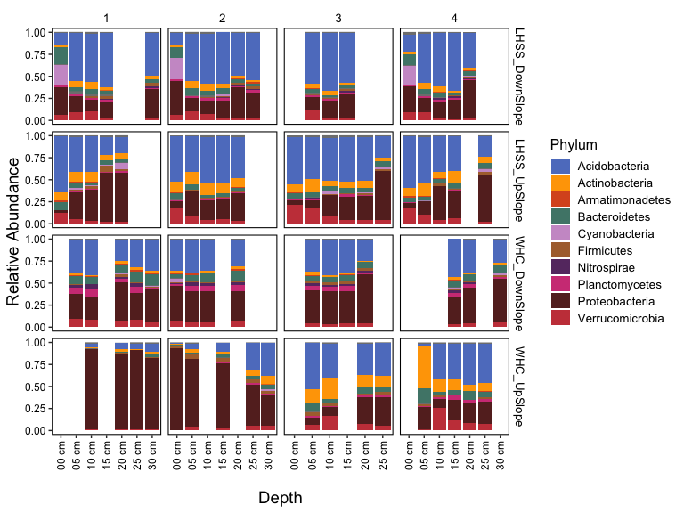

## Class

*Note:* Bacterial and archaeal classes with a global abundance of ≤ 2.8% relative abundance have been agglomerated into “≤ 2.8% relative abundance”. Vertical facets represent pits 1-4 and horizontal facets represent each basin-by-reach.

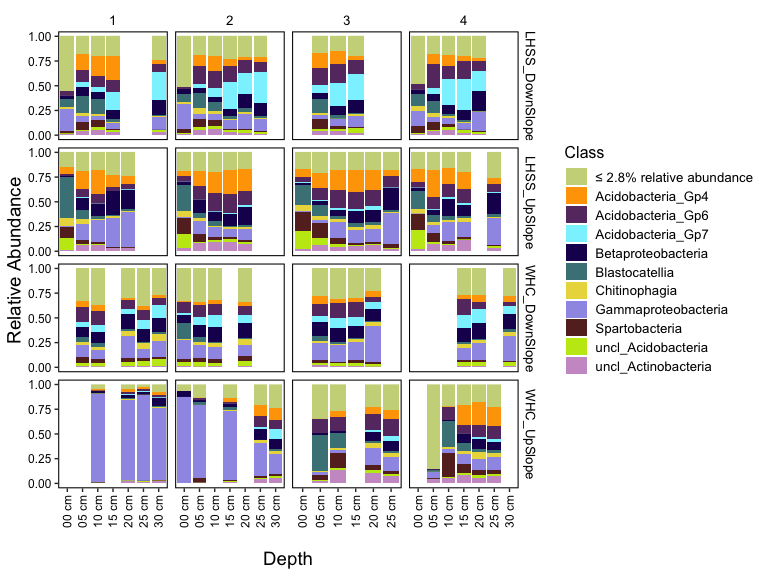

## Order

*Note:* Bacterial and archaeal orders with a global abundance of ≤ 3.7% relative abundance have been agglomerated into “≤ 3.7% relative abundance”. Vertical facets represent pits 1-4 and horizontal facets represent each basin-by-reach.

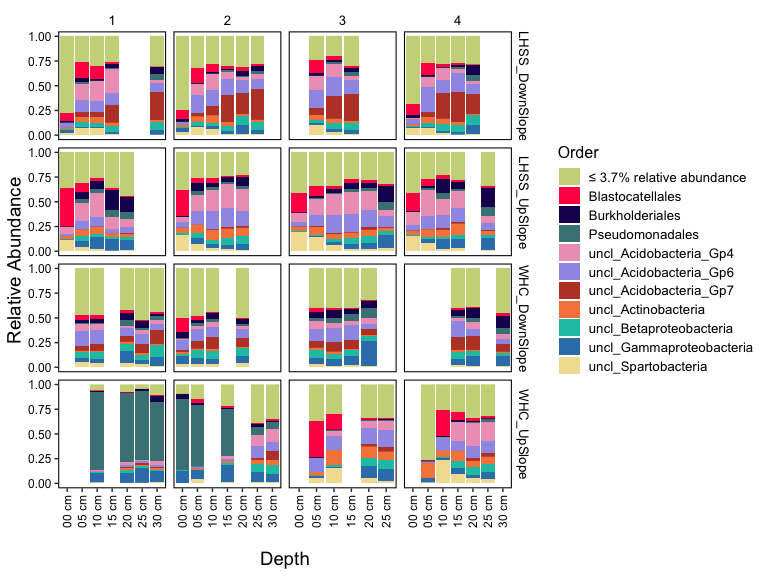

## Family

*Note:* Bacterial and archaeal families with a global abundance of ≤ 3.7% relative abundance have been agglomerated into “≤ 3.7% relative abundance”. Vertical facets represent pits 1-4 and horizontal facets represent each basin-by-reach.

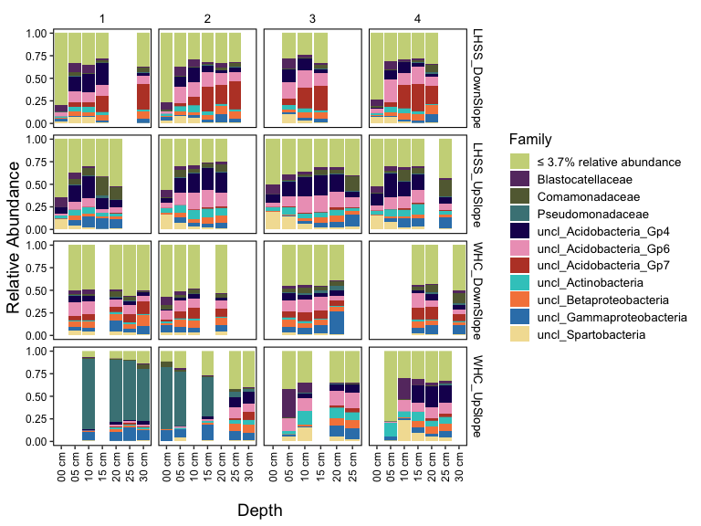